# Biostatistical Computing, PHC 6068

# Frequentist and Bayesian philosophy

- Frequentist:
  - parameters $\theta$ are fixed
  - data $X$ are random variables
  - Goal: create procedures with frequency guarantees
- Bayesian:
  - parameters $\theta$ are random variables
  - data $X$ are random variables
  - analyze beliefs

# An example of linear regression

- Underlying truth: $n=100$, $\alpha=0$, $\beta=2$, $\sigma^2=0.5$.
- Simulate iid samples: $x_i \sim N(0,1)$, $y_i \sim N(\alpha + \beta x_i,\sigma^2)$. ($i = 1, \ldots, 100$)
- Purpose: want to infer $\alpha$, $\beta$, $\sigma^2$.
- Set up priors: $\alpha \sim N(\alpha_0, \tau_a^2)$, $\beta \sim N(\beta_0, \tau_b^2)$, $\sigma^2 \sim IG(\nu, \mu)$. $\alpha_0 = 0$, $\beta_0 = 0$, $\tau_a^2 = 10$, $\tau_b^2 = 10$, $\nu=3$, $\mu=3$.
- Posterior can be derived using Bayes rule:
  - $var_\alpha \doteq 1/(1/\tau_a^2 + n/\sigma^2)$, $var_\beta \doteq 1/(1/\tau_b^2 + \sum_{i=1}^n x_i^2/\sigma^2)$
  - $\alpha | x_1^n, y_1^n, \beta, \sigma^2 \sim N(var_\alpha(\sum_{i=1}^n (y_i - \beta x_i)/\sigma^2 + \alpha_0 / \tau_a^2), var_\alpha)$
  - $\beta | x_1^n, y_1^n, \alpha, \sigma^2 \sim N(var_\beta(\sum_{i=1}^n \big( (y_i - \alpha) x_i \big) /\sigma^2 + \beta_0 / \tau_b^2), var_\beta)$
  - $\sigma^2 | x_1^n, y_1^n, \alpha, \beta \sim IG(\nu + n/2, \mu + \sum_{i=1}^n (y_i - \alpha - \beta x_i)^2/2)$

# Demonstrate the R code

- MCMC simulation 1,000 times.
- Visualization of MCMC chain
- Remove burning 100.
- Distribution of parameter.
- Auto correlation. (ACF)
- Effective samples.
- Posterior mean.
- chain mixing.

# Demonstrate the R code

```r
set.seed(32611)
n = 100; alpha = 0; beta=2; sig2=0.5;true=c(alpha,beta,sig2)
x=rnorm(n)
y=rnorm(n,alpha+beta*x,sqrt(sig2))
# Prior hyperparameters
alpha0=0;tau2a=10;beta0=0;tau2b=10;nu0=3;s02=1;nu0s02 = nu0*s02
# Setting up starting values
alpha=0;beta=0;sig2=1
# Gibbs sampler
M = 1000
draws = matrix(0,M,3)
draws[1,] <- c(alpha,beta,sig2)
for(i in 2:M){
  var_alpha = 1/(1/tau2a + n/sig2)
  mean = var_alpha*(sum(y-beta*x)/sig2 + alpha0/tau2a)
  alpha = rnorm(1,mean,sqrt(var_alpha))
  var_beta = 1/(1/tau2b + sum(x^2)/sig2)
  mean = var_beta*(sum((y-alpha)*x)/sig2+beta0/tau2b)
  beta = rnorm(1,mean,sqrt(var_beta))
  sig2 = 1/rgamma(1,(nu0+n/2),(nu0s02+sum((y-alpha-beta*x)^2)/2))
  draws[i,] = c(alpha,beta,sig2)
}
```

# Check Gibbs sampling result

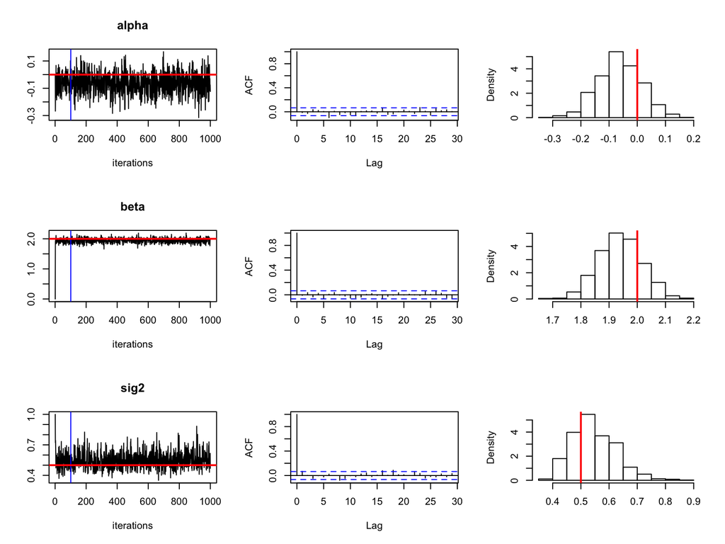

```r
# Markov chain + marginal posterior
names = c('alpha','beta','sig2')
colnames(draws) <- names
ind = 101:M
par(mfrow=c(3,3))
for(i in 1:3){
  ts.plot(draws[,i],xlab='iterations',ylab="",main=names[i])
  abline(v=ind[1],col=4)
  abline(h=true[i],col=2,lwd=2)
  acf(draws[ind,i],main="")
  hist(draws[ind,i],prob=T,main="",xlab="")
  abline(v=true[i],col=2,lwd=2)
}
```

# Posterior mean

```r
colMeans(draws[101:M,])
```

```
##       alpha        beta        sig2
## -0.06394806  1.93993716  0.54674891
```

# MCMC simulation, number of iterations (e.g. 1,000)

- Large number of iterations will tend to recover the underlying distribution in higher resolution.
- Large number of iterations will also add computational burden.

# Burnin period 1

- If the initial value is within the range of **stationary distribution**, we won’t need burnin.
- If the initial value is out the range of stationary distribution, we need need to discard them.

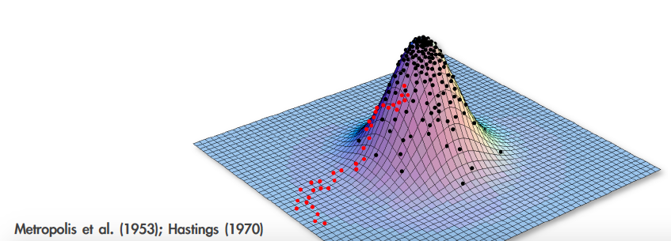

# A burnin example from my own research

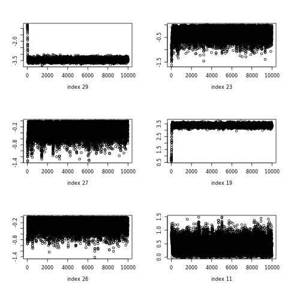

# Auto correlation

$$R_x(k) = \frac
{\sum_{t=1}^{n-k} (x_t - \bar{x})(x_{t+k} - \bar{x})}
{\sum_{t=1}^{n-k} (x_t - \bar{x})^2}$$

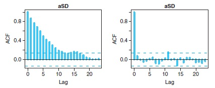

- The first-order AC $R_x(1)$ can be used to estimate the Sample Size Inflation Factor (SSIF):
  $$s_x = \frac{1 + R_x(1)}{1 - R_x(1)}$$
- If we took n samples with SSIF, then the effective sample size is $n/s_x$

# How to deal with autocorrelation?

High autocorrelation leads to smaller effective sample size.

- Design smarter algorithm to make auto-correlation smaller.
- Thining: Only take samples every 10 iterations.
- Just keep everything and make the Markov chain longer.

# Chain mixing

- Monitor convergence by plotting samples (of r.v.s) from multiple chains.
  - If the chains are well mixed (left), they are probably converged.
  - If the chains are poorly-mixed (right), we should continue burn-in.

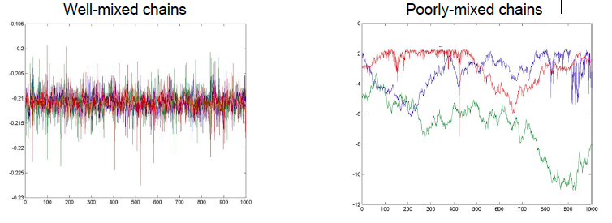

# Converge

- How to monitor the convergence of the Markov chain.
  - Monitor the pattern of samples.
  - Monitor likelihood.

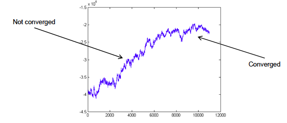

# Why Gibbs is MH with $A(x'|x) = 1$?

- The Gibbs sampling proposal distribution is:
  $$q(x'_i, \textbf{x}_{-i} | x_i, \textbf{x}_{-i} ) = p(x'_i | \textbf{x}_{-i})$$
- Applying MH to this proposed distribution:

$$\begin{align*}
A(x'_i, \textbf{x}_{-i} | x_i, \textbf{x}_{-i} ) &= \min
\bigg( 1,
\frac{p(x'_i,\textbf{x}_{-i}) q(x_i, \textbf{x}_{-i} | x'_i, \textbf{x}_{-i} ) }
{p(x_i,\textbf{x}_{-i}) q(x'_i, \textbf{x}_{-i} | x_i, \textbf{x}_{-i} )}
\bigg) \\
&= \min
\bigg( 1,
\frac{p(x'_i,\textbf{x}_{-i}) p(x_i| \textbf{x}_{-i} ) }
{p(x_i,\textbf{x}_{-i}) p(x'_i, |\textbf{x}_{-i} )}
\bigg) \\
&= \min
\bigg( 1,
\frac{p(x'_i| \textbf{x}_{-i} ) p(\textbf{x}_{-i}) p(x_i| \textbf{x}_{-i} ) }
{p(x_i| \textbf{x}_{-i} ) p( \textbf{x}_{-i}) p(x'_i |\textbf{x}_{-i} )}
\bigg) \\
&= \min (1,1)\\
&= 1
\end{align*}$$

- Gibbs sampling is a MH with acceptance rate 100%.

# References

- BDA3

```r
knitr::purl("Gibbs.rmd", output = "Gibbs.R ", documentation = 2)
```

```
##
##
## processing file: Gibbs.rmd
```

[output not shown]

```
## output file: Gibbs.R
```

```
## [1] "Gibbs.R "
```